# Moje narzędzia #2.5 - Feature Selection - Kwiecień 2020 [''Stroke_Prediction'']

```python
import pandas as pd
import numpy as np
import seaborn as sns
import matplotlib.pyplot as plt
import warnings

warnings.filterwarnings("ignore")

%matplotlib inline

df= pd.read_csv('/home/wojciech/Pulpit/1/Stroke_Prediction.csv')
print(df.shape)
print()
print(df.columns)
df.head(3)
```

```
(43400, 12)

Index(['ID', 'Gender', 'Age_In_Days', 'Hypertension', 'Heart_Disease',
       'Ever_Married', 'Type_Of_Work', 'Residence', 'Avg_Glucose', 'BMI',
       'Smoking_Status', 'Stroke'],
      dtype='object')
```

|  | ID | Gender | Age_In_Days | Hypertension | Heart_Disease | Ever_Married | Type_Of_Work | Residence | Avg_Glucose | BMI | Smoking_Status | Stroke |
| --- | --- | --- | --- | --- | --- | --- | --- | --- | --- | --- | --- | --- |
| 0 | 31153 | Male | 1104.0 | 0 | 0 | No | children | Rural | 95.12 | 18.0 | NaN | 0 |
| 1 | 30650 | Male | 21204.0 | 1 | 0 | Yes | Private | Urban | 87.96 | 39.2 | never smoked | 0 |
| 2 | 17412 | Female | 2928.0 | 0 | 0 | No | Private | Urban | 110.89 | 17.6 | NaN | 0 |

### Kasuje bezsensowne kolumny

```python
# del df['Unnamed: 0']
# del df['Unnamed: 0.1']
```

### Wielkość bazy df jest ogromna - wyciągam tylko 100% losowo wybranych rekordów

Taka metoda jest najbardziej reprezentatywna i oszczędza zasoby komputera.

```python
df2 = df.sample(frac = 1.00, random_state=10)
df2.shape
```

```
(43400, 12)
```

## Wyświetlenie braków (własnej roboty)

```python
a,b = df2.shape     #<- ile mamy kolumn
b

print('NUMBER OF EMPTY RECORDS vs. FULL RECORDS')
print('----------------------------------------')
for i in range(1,b):
    i = df2.columns[i]
    r = df2[i].isnull().sum()
    h = df2[i].count()
    pr = (r/h)*100

    if r > 0:
        print(i,"--------",r,"--------",h,"--------",pr)
```

```
NUMBER OF EMPTY RECORDS vs. FULL RECORDS
----------------------------------------
BMI -------- 1462 -------- 41938 -------- 3.4860985263961086
Smoking_Status -------- 13292 -------- 30108 -------- 44.14773482130995
```

## Nie warto kasować rekordów z brakami tylko warto wstawiać tam wartości z poza zakresu

Wyszukuje tylko puste rekordy

```python
null_value_stats = df2.isnull().sum(axis=0)
null_value_stats[null_value_stats != 0]
```

```
BMI                1462
Smoking_Status    13292
dtype: int64
```

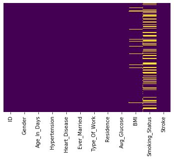

```python
import seaborn as sns

sns.heatmap(df2.isnull(),yticklabels=False,cbar=False,cmap='viridis')
```

Wstawia w puste miejsca wartości z poza zakresu

```python
df2.fillna(7777, inplace=True)
```

## Przegląd danych pod kontem formatu i ilości wartości unikalnych (własnej roboty)

```python
a,b = df2.shape     #<- ile mamy kolumn
b

import numpy as np

for i in range(1,b):
    i = df2.columns[i]
    h = df2[i].nunique()
    f = df2[i].dtypes

    print(f,'---nunique->',h,'---name->', i)
```

```
object ---nunique-> 3 ---name-> Gender
float64 ---nunique-> 4848 ---name-> Age_In_Days
int64 ---nunique-> 2 ---name-> Hypertension
int64 ---nunique-> 2 ---name-> Heart_Disease
object ---nunique-> 2 ---name-> Ever_Married
object ---nunique-> 5 ---name-> Type_Of_Work
object ---nunique-> 2 ---name-> Residence
float64 ---nunique-> 12543 ---name-> Avg_Glucose
float64 ---nunique-> 556 ---name-> BMI
object ---nunique-> 4 ---name-> Smoking_Status
int64 ---nunique-> 2 ---name-> Stroke
```

## Które z tych funkcji są kategoryczne? (własnej roboty)

Stawiam dwa warunki:

1. funkcja jest kategoryczna bo ma format 'object'
2. funkcja jest kategoryczna bo ma do 10 unikalnych wartości

```python
a,b = df2.shape     #<- ile mamy kolumn
b

print('ONLY DISCRETE FUNCTION')
print('----------------------')
for i in range(1,b):
    i = df2.columns[i]
    f = df2[i].dtypes
    h = df2[i].nunique()

    if f == np.object or h<=10:
        print(i,"---",f,"---",h)
```

```
ONLY DISCRETE FUNCTION
----------------------
Gender --- object --- 3
Hypertension --- int64 --- 2
Heart_Disease --- int64 --- 2
Ever_Married --- object --- 2
Type_Of_Work --- object --- 5
Residence --- object --- 2
Smoking_Status --- object --- 4
Stroke --- int64 --- 2
```

#### Potrzebujemy listy z numerami kolumnaby użyć jej w CatBoost¶

```python
import numpy as np
a,b = df2.shape     #<- ile mamy kolumn
b

print()
categorical_fun = np.where((df2.dtypes == np.object)|(df2.nunique() <= 15))[0]
x1 = len(categorical_fun)
print('categorical_fun: ',x1)
print('categorical_fun: ',categorical_fun)
print()
numerical_fun = np.where((df2.dtypes != np.object)&(df2.nunique() > 15))[0]
x2 = len(numerical_fun)
print('numerical_fun: ',x2)
print('numerical_fun: ',numerical_fun)
print()
print('LICZBA KOLUMN MA SIĘ ZGADZAĆ!')
print('all columns:                     ',b)
print('numerical_fun + categorical_fun: ',x1+x2)
```

```
categorical_fun:  8
categorical_fun:  [ 1  3  4  5  6  7 10 11]

numerical_fun:  4
numerical_fun:  [0 2 8 9]

LICZBA KOLUMN MA SIĘ ZGADZAĆ!
all columns:                      12
numerical_fun + categorical_fun:  12
```

## Uwaga!

#### 1. dane categorialne nie muszą mieć tylko formatu tekstowego,

#### 2. dane tekstowe trzeba przerobić do formatu numerycznego

### Narzędzie do automatycznego kodowania zmiennych dyskretnych (własnej roboty)

```python
a,b = df2.shape     #<- ile mamy kolumn
b

print('DISCRETE FUNCTIONS CODED')
print('------------------------')
for i in range(1,b):
    i = df2.columns[i]
    f = df2[i].dtypes
    if f == np.object:
        print(i,"---",f)

        if f == np.object:

            df2[i] = pd.Categorical(df2[i]).codes

            continue
```

```
DISCRETE FUNCTIONS CODED
------------------------
Gender --- object
Ever_Married --- object
Type_Of_Work --- object
Residence --- object
Smoking_Status --- object
```

### Narzędzie do automatycznej zmiany znaku na plus (własnej roboty)

```python
(df2 < 0).all(1)
```

```
40901    False
35943    False
34620    False
15550    False
40360    False
         ...
40059    False
28017    False
29199    False
40061    False
17673    False
Length: 43400, dtype: bool
```

```python
df2.head()
```

|  | ID | Gender | Age_In_Days | Hypertension | Heart_Disease | Ever_Married | Type_Of_Work | Residence | Avg_Glucose | BMI | Smoking_Status | Stroke |
| --- | --- | --- | --- | --- | --- | --- | --- | --- | --- | --- | --- | --- |
| 40901 | 57244 | 0 | 17546.0 | 0 | 0 | 1 | 2 | 1 | 56.54 | 35.9 | 2 | 0 |
| 35943 | 12001 | 0 | 20844.0 | 0 | 0 | 1 | 2 | 0 | 86.48 | 23.8 | 2 | 0 |
| 34620 | 25334 | 0 | 29612.0 | 0 | 0 | 1 | 2 | 0 | 86.86 | 31.7 | 2 | 0 |
| 15550 | 52679 | 0 | 16455.0 | 0 | 0 | 1 | 2 | 1 | 79.49 | 31.6 | 2 | 0 |
| 40360 | 40046 | 0 | 28872.0 | 0 | 0 | 1 | 3 | 0 | 80.47 | 28.0 | 2 | 0 |

### Szukamy ujemnych wartości i je zmieniamy (przesuwamy) aby były dodatnie

Filtr Ch2 nie lubi ujemnych wartości

```python
a,b = df2.shape     #<- ile mamy kolumn
b

print('NEGATIVE VALUES')
print('---------------')
for i in range(1,b):
    i = df2.columns[i]
    f = df2[i].min()
    if f < 0:
        print(i,"---",f)
```

```
NEGATIVE VALUES
---------------
Age_In_Days --- -16381.0
```

#### Najpierw trzeba się upewnić czy ujemna wartość to nie jest ewidentny błąd

```python
(df2['Age_In_Days']==-16381.0).sum()
```

```
1
```

```python
df2['Age_In_Days'] = df2['Age_In_Days'].replace(-16381.0,0)
```

#### usuwamy wartości ujemne (przesuwamy)

```python
#df2['Age_In_Day'] = df2['Age_In_Day']+(-df2['Age_In_Day'].min())
#df2['cons_conf_idx'] = df2['cons_conf_idx']+(-df2['cons_conf_idx'].min())
```

### Sprawdzam czy nie ma już zmiennych tekstowych i wartości pustych

```python
null_value_stats = df2.isnull().sum(axis=0)
null_value_stats[null_value_stats != 0]
```

```
Series([], dtype: int64)
```

```python
obj = np.where(df2.dtypes == np.object)
obj
```

```
(array([], dtype=int64),)
```

## Ustawiamy zmienną wynikową (manualnie)

```python
result = 'Stroke'
```

# Feature Selection

### Wydzielam zmienne kategoryczne

```python
cat_c = df2.columns[categorical_fun]

df_cat= df2[cat_c]
df_cat.head(3)
```

|  | Gender | Hypertension | Heart_Disease | Ever_Married | Type_Of_Work | Residence | Smoking_Status | Stroke |
| --- | --- | --- | --- | --- | --- | --- | --- | --- |
| 40901 | 0 | 0 | 0 | 1 | 2 | 1 | 2 | 0 |
| 35943 | 0 | 0 | 0 | 1 | 2 | 0 | 2 | 0 |
| 34620 | 0 | 0 | 0 | 1 | 2 | 0 | 2 | 0 |

```python
X_cat = df_cat.drop(result, axis=1)
y = df_cat[result]

from sklearn.model_selection import train_test_split
X_train, X_test, y_train, y_test = train_test_split(X_cat, y, test_size=0.20, random_state=123,stratify=y)
# Jeżeli się rzuca wtedy wycinamy stratify=y.
```

## Filter

### 1. Chi-Squered and Mutual Information

[figure not shown]

## Mutual Information Feature Selection: Mutual_info_classif ()

Mmutual Information is usually used in the construction of decision trees for selecting variables.

```python
from sklearn.feature_selection import mutual_info_classif
from sklearn.feature_selection import SelectKBest


def select_features_MIC(X_train, y_train, X_test):
    MIC = SelectKBest(score_func=mutual_info_classif, k='all')
    MIC.fit(X_train, y_train)
    X_train_MIC = MIC.transform(X_train)
    X_test_MIC = MIC.transform(X_test)
    return X_train_MIC, X_test_MIC, MIC
```

```python
X_train_MIC, X_test_MIC, MIC = select_features_MIC(X_train, y_train, X_test)
```

```python
for i in range(len(MIC.scores_)):
    r = MIC.scores_[i]
    if r>0:
        print('Feature %d: %f' % (i, MIC.scores_[i]))
```

```
Feature 2: 0.000933
Feature 3: 0.005201
Feature 4: 0.007316
Feature 6: 0.000893
```

```python
importance_mic = np.round(MIC.scores_, decimals=3)
importance_mic
```

```
array([0.   , 0.   , 0.001, 0.005, 0.007, 0.   , 0.001])
```

```python
KOT_MIC = dict(zip(df2, importance_mic))
KOT_sorted_keys_MIC = sorted(KOT_MIC, key=KOT_MIC.get, reverse=True)

for r in KOT_sorted_keys_MIC:
    m = KOT_MIC[r]
    if m>0:
        print (r, KOT_MIC[r])
```

```
Heart_Disease 0.007
Hypertension 0.005
Age_In_Days 0.001
Type_Of_Work 0.001
```

## Feature Selection by Chi-Squared

```python
from sklearn.feature_selection import SelectKBest
from sklearn.feature_selection import chi2

def select_features_CH2(X_train, y_train, X_test):
    CH2 = SelectKBest(score_func=chi2, k=4)
    CH2.fit(X_train, y_train)
    X_train_CH2 = CH2.transform(X_train)
    X_test_CH2 = CH2.transform(X_test)
    return X_train_CH2, X_test_CH2, CH2
```

```python
X_train_CH2, X_test_CH2, CH2 = select_features_CH2(X_train, y_train, X_test)
```

```python
for i in range(len(CH2.scores_)):
    r = CH2.scores_[i]
    if r>50:
        print('Feature %d: %f' % (i, CH2.scores_[i]))
```

```
Feature 1: 186.625863
Feature 2: 475.363834
Feature 3: 64.109716
```

## Sprawdzenie czy dobrze przyporządkował. Trzeba porównać nazwę poniżej z nazwą po zip.

```python
df2.columns[3]
```

```
'Hypertension'
```

```python
importance_CH2 = np.round(CH2.scores_, decimals=3)
importance_CH2

KOT_CH2 = dict(zip(df2, importance_CH2))
KOT_CH2_sorted_keys = sorted(KOT_CH2, key=KOT_CH2.get, reverse=True)

for r in KOT_CH2_sorted_keys:
    g = KOT_CH2[r]
    if g>50:
        print (KOT_CH2[r],r)
```

```
475.364 Age_In_Days
186.626 Gender
64.11 Hypertension
```

## Tworzę tabelkę podsumowującą: Chi-Squared i Mutual Information

```python
feature_name = X_cat.columns

feature_selection_df = pd.DataFrame({'Feature':feature_name, 'Chi-Squared':importance_CH2, 'Mutual Information':importance_mic})
feature_selection_df["Rank_MIC"] = feature_selection_df["Mutual Information"].rank(method ='average')
feature_selection_df["Rank_CH2"] = feature_selection_df["Chi-Squared"].rank(method ='average')
feature_selection_df

del feature_selection_df['Chi-Squared']
del feature_selection_df['Mutual Information']

feature_selection_df['Total'] = np.sum(feature_selection_df, axis=1)
feature_selection_df = feature_selection_df.sort_values('Total',ascending=False )
feature_selection_df.head(20)
```

|  | Feature | Rank_MIC | Rank_CH2 | Total |
| --- | --- | --- | --- | --- |
| 2 | Heart_Disease | 4.5 | 7.0 | 11.5 |
| 3 | Ever_Married | 6.0 | 5.0 | 11.0 |
| 4 | Type_Of_Work | 7.0 | 3.0 | 10.0 |
| 6 | Smoking_Status | 4.5 | 4.0 | 8.5 |
| 1 | Hypertension | 2.0 | 6.0 | 8.0 |
| 0 | Gender | 2.0 | 2.0 | 4.0 |
| 5 | Residence | 2.0 | 1.0 | 3.0 |

Sprawdzam liczebność zbioru:

```python
feature_selection_df.shape ##<-- wyszła jedna zmienna 'Target'
```

```
(7, 4)
```

# Feature Selection Techniques (by filter methods): numerical_ input, categorical output

[figure not shown]

### Wydzielam zmienne numeryczne

```python
num_c = df2.columns[numerical_fun]

df_num= df2[num_c]

df_num[result] = df2[result]
df_num.head(3)
```

|  | ID | Age_In_Days | Avg_Glucose | BMI | Stroke |
| --- | --- | --- | --- | --- | --- |
| 40901 | 57244 | 17546.0 | 56.54 | 35.9 | 0 |
| 35943 | 12001 | 20844.0 | 86.48 | 23.8 | 0 |
| 34620 | 25334 | 29612.0 | 86.86 | 31.7 | 0 |

```python
X_num = df_num.drop(result, axis=1)
y = df_num[result]
```

## Redukcja zmiennych niezależnych za pomocą OLS

```python
from statsmodels.formula.api import ols
import statsmodels.api as sm

model = sm.OLS(y, sm.add_constant(X_num))
model_fit = model.fit()

print(model_fit.summary())
```

```
                            OLS Regression Results
==============================================================================
Dep. Variable:                 Stroke   R-squared:                       0.034
Model:                            OLS   Adj. R-squared:                  0.034
Method:                 Least Squares   F-statistic:                     384.3
Date:                Sat, 18 Apr 2020   Prob (F-statistic):               0.00
Time:                        10:46:19   Log-Likelihood:                 26696.
No. Observations:               43400   AIC:                        -5.338e+04
Df Residuals:                   43395   BIC:                        -5.334e+04
Df Model:                           4
Covariance Type:            nonrobust
===============================================================================
                  coef    std err          t      P>|t|      [0.025      0.975]
-------------------------------------------------------------------------------
const          -0.0329      0.002    -15.474      0.000      -0.037      -0.029
ID           7.649e-08   3.01e-08      2.545      0.011    1.76e-08    1.35e-07
Age_In_Days   2.18e-06   7.77e-08     28.063      0.000    2.03e-06    2.33e-06
Avg_Glucose     0.0001    1.5e-05      7.529      0.000    8.38e-05       0.000
BMI          8.989e-06   4.57e-07     19.688      0.000    8.09e-06    9.88e-06
==============================================================================
Omnibus:                    52683.281   Durbin-Watson:                   2.002
Prob(Omnibus):                  0.000   Jarque-Bera (JB):          4360136.753
Skew:                           6.871   Prob(JB):                         0.00
Kurtosis:                      50.141   Cond. No.                     1.51e+05
==============================================================================

Warnings:
[1] Standard Errors assume that the covariance matrix of the errors is correctly specified.
[2] The condition number is large, 1.51e+05. This might indicate that there are
strong multicollinearity or other numerical problems.
```

Wyodrębniam z powyższego zestawienia tabelę z 'P>|t|'

```python
p_values = model_fit.summary2().tables[1]['P>|t|']
```

Obrabiam tą tabelę, zaokrąglam itp.

```python
p_values = np.round(p_values, decimals=2)
p_values= p_values.sort_values(ascending=True)

p_values = p_values.to_frame()
print(p_values.shape)

p_values[p_values['P>|t|']<=0.01]   #<--wartości p-value mniejsze i równe 0.01
```

```
(5, 1)
```

|  | P>\|t\| |
| --- | --- |
| const | 0.00 |
| Age_In_Days | 0.00 |
| Avg_Glucose | 0.00 |
| BMI | 0.00 |
| ID | 0.01 |

Dodaje ranking ważności (odwrotny - najlepsze są te gdzie p-value<0.01).

```python
p_values.drop('const', axis=0, inplace=True)
```

```python
p_values["p-value_rank"] = p_values["P>|t|"].rank(method ='min',ascending=False)
p_values.head(5)
```

|  | P>\|t\| | p-value_rank |
| --- | --- | --- |
| Age_In_Days | 0.00 | 2.0 |
| Avg_Glucose | 0.00 | 2.0 |
| BMI | 0.00 | 2.0 |
| ID | 0.01 | 1.0 |

Mnożę razy dwa ponieważ dla zmiennych kategorycznych mam dwa testy a dla zmiennych numerycznych mam jeden test. Chodzi o wyrównanie szans.

```python
del p_values['P>|t|']
p_values['p-value_x2'] = p_values['p-value_rank']*2
del p_values['p-value_rank']
p_values.head(3)
```

|  | p-value_x2 |
| --- | --- |
| Age_In_Days | 4.0 |
| Avg_Glucose | 4.0 |
| BMI | 4.0 |

```python
feature_selection_df=feature_selection_df.set_index('Feature')
```

```python
del feature_selection_df['Total']
```

```python
feature_selection_df.shape
```

```
(7, 2)
```

```python
p_values.shape
```

```
(4, 1)
```

```python
df6 = pd.concat([p_values,feature_selection_df], sort=True)
df6
```

|  | Rank_CH2 | Rank_MIC | p-value_x2 |
| --- | --- | --- | --- |
| Age_In_Days | NaN | NaN | 4.0 |
| Avg_Glucose | NaN | NaN | 4.0 |
| BMI | NaN | NaN | 4.0 |
| ID | NaN | NaN | 2.0 |
| Heart_Disease | 7.0 | 4.5 | NaN |
| Ever_Married | 5.0 | 6.0 | NaN |
| Type_Of_Work | 3.0 | 7.0 | NaN |
| Smoking_Status | 4.0 | 4.5 | NaN |
| Hypertension | 6.0 | 2.0 | NaN |
| Gender | 2.0 | 2.0 | NaN |
| Residence | 1.0 | 2.0 | NaN |

```python
print('columns: ',df6.columns)
print(df6.shape)
```

```
columns:  Index(['Rank_CH2', 'Rank_MIC', 'p-value_x2'], dtype='object')
(11, 3)
```

# Wrapper Method

### Feature Selection Techniques – Backward Elimination

```python
X = df2.drop(result, axis=1)
y = df2[result]

from sklearn.model_selection import train_test_split

X_train, X_test, y_train, y_test = train_test_split(X, y, test_size=0.20, random_state=123)
# Jeżeli się rzuca wtedy wycinamy stratify=y.
```

# Recursive Feature Elimination (RFE)

Ustawiam liczbę zmiennych, które pozostaną w modelu

```python
Num_v  =  15
```

```python
from sklearn.feature_selection import RFE
from sklearn.linear_model import LinearRegression

model=LinearRegression()
rfe=RFE(model,Num_v)

# Standaryzacja zmiennych

X_rfe = rfe.fit_transform(X,y)

model.fit(X_rfe,y)

print('Number of selected functions:  ',rfe.n_features_)
print()
print('The mask of selected features: ',rfe.support_)
print()
print('The feature ranking:',rfe.ranking_)
print()
print('The external estimator:',rfe.estimator_)
```

```
Number of selected functions:   11

The mask of selected features:  [ True  True  True  True  True  True  True  True  True  True  True]

The feature ranking: [1 1 1 1 1 1 1 1 1 1 1]

The external estimator: LinearRegression(copy_X=True, fit_intercept=True, n_jobs=None, normalize=False)
```

#### Metoda zip na wyświetlenie rankingu cech

```python
PPS = rfe.ranking_

KOT_MIC = dict(zip(df, PPS))
KOT_sorted_keys_MIC = sorted(KOT_MIC, key=KOT_MIC.get, reverse=True)

for r in KOT_sorted_keys_MIC:
    print (r, KOT_MIC[r])
```

```
ID 1
Gender 1
Age_In_Days 1
Hypertension 1
Heart_Disease 1
Ever_Married 1
Type_Of_Work 1
Residence 1
Avg_Glucose 1
BMI 1
Smoking_Status 1
```

## Embedded Method (Lasso)

```python
Num_v = 15
```

```python
from sklearn import linear_model

#rlasso = RandomizedLasso(alpha=0.025)

# Standaryzacja zmiennych

lasso = linear_model.Lasso(alpha=0.1, positive=True)
lasso.fit(X, y)


#print(lasso.coef_)
#print()
#print(lasso.intercept_)
#print()
#print(lasso.score(X,y))

lasso = lasso.coef_
```

Metoda zip na wyświetlenie ocen cechy

```python
PPS = lasso

#PPS = np.round(PPS, decimals=8)

KOT_lasso = dict(zip(df, PPS))
KOT_sorted_keys_lasso = sorted(KOT_lasso, key=KOT_lasso.get, reverse=True)


for r in KOT_sorted_keys_lasso:
    print (r, (KOT_lasso[r]))
```

```
Avg_Glucose 5.60907469576232e-05
BMI 9.09617189841293e-06
Age_In_Days 2.2456563759498426e-06
ID 7.970580791250456e-08
Gender 0.0
Hypertension 0.0
Heart_Disease 0.0
Ever_Married 0.0
Type_Of_Work 0.0
Residence 0.0
Smoking_Status 0.0
```

## RandomForestClassifier

```python
from sklearn.ensemble import RandomForestClassifier

rfc = RandomForestClassifier()
rfc.fit(X, y)
```

```
RandomForestClassifier(bootstrap=True, class_weight=None, criterion='gini',
                       max_depth=None, max_features='auto', max_leaf_nodes=None,
                       min_impurity_decrease=0.0, min_impurity_split=None,
                       min_samples_leaf=1, min_samples_split=2,
                       min_weight_fraction_leaf=0.0, n_estimators=10,
                       n_jobs=None, oob_score=False, random_state=None,
                       verbose=0, warm_start=False)
```

```python
importance_RFC = rfc.feature_importances_
```

```python
importance_RFC = np.round(importance_RFC, decimals=3)
importance_RFC
```

```
array([0.213, 0.024, 0.232, 0.02 , 0.014, 0.009, 0.036, 0.023, 0.211,
       0.174, 0.043])
```

```python
KOT = dict(zip(X, importance_RFC))
KOT_sorted_keys = sorted(KOT, key=KOT.get, reverse=True)

for r in KOT_sorted_keys:
    print (r, KOT[r])

    KOT
```

```
Age_In_Days 0.232
ID 0.213
Avg_Glucose 0.211
BMI 0.174
Smoking_Status 0.043
Type_Of_Work 0.036
Gender 0.024
Residence 0.023
Hypertension 0.02
Heart_Disease 0.014
Ever_Married 0.009
```

## CatBoostClasiffier

```python
## Potrzebujemy listy z numerami kolumn kategorycznych dla CatBoost

import numpy as np
a,b = df2.shape     #<- ile mamy kolumn
b

print()
cat_fun = np.where((df.dtypes == np.object))[0]    #|(df2.nunique() <= 3)
x1 = len(cat_fun)
print('cat_fun: ',x1)
print('cat_fun: ',cat_fun)
```

```
cat_fun:  5
cat_fun:  [ 1  5  6  7 10]
```

Użycie modelu w celu wskazania najlepszych cech

```python
from catboost import CatBoostClassifier, Pool, cv

train_pool = Pool(X_train, y_train, cat_features=cat_fun)
CBC = CatBoostClassifier(iterations=50, random_seed=42, logging_level='Silent').fit(train_pool)
```

```python
feature_importances = CBC.get_feature_importance(train_pool)
```

```python
feature_names = X_train.columns
feature_names
```

```
Index(['ID', 'Gender', 'Age_In_Days', 'Hypertension', 'Heart_Disease',
       'Ever_Married', 'Type_Of_Work', 'Residence', 'Avg_Glucose', 'BMI',
       'Smoking_Status'],
      dtype='object')
```

```python
for score, name in sorted(zip(feature_importances, feature_names), reverse=True):
    print('{}: {}'.format(name, score))
```

```
Age_In_Days: 44.25589431919381
BMI: 17.63948955941283
ID: 13.389162064312382
Avg_Glucose: 10.512313663335691
Hypertension: 4.3898828139332
Heart_Disease: 4.025887833419852
Ever_Married: 3.01703473760544
Residence: 2.7703350087867804
Type_Of_Work: 0.0
Smoking_Status: 0.0
Gender: 0.0
```

# Zestawienie informacji z modeli

Sprawdzenie wymiarów:

```python
feature_name = X.columns
print('feature_name:                      ',feature_name.shape)
print('RandomForestClassifier_RFC:        ',importance_RFC.shape)
print('Recursive Feature Elimination_RFE: ',rfe.ranking_.shape)
print('lasso:                             ',lasso.shape)
print('CatBoostClassifier:                ',feature_importances.shape)
```

```
feature_name:                       (11,)
RandomForestClassifier_RFC:         (11,)
Recursive Feature Elimination_RFE:  (11,)
lasso:                              (11,)
CatBoostClassifier:                 (11,)
```

## Tworzymy tabelę porównawczą modeli:

```python
feat_sel_df = pd.DataFrame({'Feature':feature_name, 'RandomForestClassifier':importance_RFC, 'Recursive Feature Elimination (RFE)':rfe.ranking_,'lasso':lasso,'CatBoostClassifier':feature_importances})
```

```python
feat_sel_df.head(3)
```

|  | Feature | RandomForestClassifier | Recursive Feature Elimination (RFE) | lasso | CatBoostClassifier |
| --- | --- | --- | --- | --- | --- |
| 0 | ID | 0.213 | 1 | 7.970581e-08 | 13.389162 |
| 1 | Gender | 0.024 | 1 | 0.000000e+00 | 0.000000 |
| 2 | Age_In_Days | 0.232 | 1 | 2.245656e-06 | 44.255894 |

Jak widać oceny są niekompatibilne do siebie dlatego zrobiłem ocenę rankingową

### Tworzymy tabelę rankingową dla Wrapper Method

```python
feat_sel_df["RFC"] = feat_sel_df["RandomForestClassifier"].rank(method ='average')
feat_sel_df["RFE"] = feat_sel_df["Recursive Feature Elimination (RFE)"].rank(method ='average')
feat_sel_df["Lasso"] = feat_sel_df["lasso"].rank(method ='average')
feat_sel_df["CBC"] = feat_sel_df["CatBoostClassifier"].rank(method ='average')

del feat_sel_df['RandomForestClassifier']
del feat_sel_df['Recursive Feature Elimination (RFE)']
del feat_sel_df['lasso']
del feat_sel_df['CatBoostClassifier']
```

```python
feat_sel_df['Total'] = feat_sel_df['RFC']+feat_sel_df['RFE']+feat_sel_df['Lasso']
feat_sel_df = feat_sel_df.sort_values('Total',ascending=False )
feat_sel_df.head(20)
```

|  | Feature | RFC | RFE | Lasso | CBC | Total |
| --- | --- | --- | --- | --- | --- | --- |
| 2 | Age_In_Days | 11.0 | 6.0 | 9.0 | 11.0 | 26.0 |
| 8 | Avg_Glucose | 9.0 | 6.0 | 11.0 | 8.0 | 26.0 |
| 0 | ID | 10.0 | 6.0 | 8.0 | 9.0 | 24.0 |
| 9 | BMI | 8.0 | 6.0 | 10.0 | 10.0 | 24.0 |
| 10 | Smoking_Status | 7.0 | 6.0 | 4.0 | 2.0 | 17.0 |
| 6 | Type_Of_Work | 6.0 | 6.0 | 4.0 | 2.0 | 16.0 |
| 1 | Gender | 5.0 | 6.0 | 4.0 | 2.0 | 15.0 |
| 7 | Residence | 4.0 | 6.0 | 4.0 | 4.0 | 14.0 |
| 3 | Hypertension | 3.0 | 6.0 | 4.0 | 7.0 | 13.0 |
| 4 | Heart_Disease | 2.0 | 6.0 | 4.0 | 6.0 | 12.0 |
| 5 | Ever_Married | 1.0 | 6.0 | 4.0 | 5.0 | 11.0 |

```python
del feat_sel_df['Total']  # <- usuwam podsumowanie 'Total'
```

#### Ustawiamy indeks 'Feature' w tabeli Filtrów

```python
print(df6.shape)   ## obie tabele filtrów i modeli muszą mieć tyle samo wierszy!
print(df6.index)
df6.reset_index()
```

```
(11, 3)
Index(['Age_In_Days', 'Avg_Glucose', 'BMI', 'ID', 'Heart_Disease',
       'Ever_Married', 'Type_Of_Work', 'Smoking_Status', 'Hypertension',
       'Gender', 'Residence'],
      dtype='object')
```

|  | index | Rank_CH2 | Rank_MIC | p-value_x2 |
| --- | --- | --- | --- | --- |
| 0 | Age_In_Days | NaN | NaN | 4.0 |
| 1 | Avg_Glucose | NaN | NaN | 4.0 |
| 2 | BMI | NaN | NaN | 4.0 |
| 3 | ID | NaN | NaN | 2.0 |
| 4 | Heart_Disease | 7.0 | 4.5 | NaN |
| 5 | Ever_Married | 5.0 | 6.0 | NaN |
| 6 | Type_Of_Work | 3.0 | 7.0 | NaN |
| 7 | Smoking_Status | 4.0 | 4.5 | NaN |
| 8 | Hypertension | 6.0 | 2.0 | NaN |
| 9 | Gender | 2.0 | 2.0 | NaN |
| 10 | Residence | 1.0 | 2.0 | NaN |

#### Ustawiamy indeks 'Feature' w tabeli Wrapper Method (kolanem dopychamy)

```python
feat_sel_df.reset_index()
feat_sel_df= feat_sel_df.set_index('Feature')
print(feat_sel_df.shape)
print(feat_sel_df.index)
print(feat_sel_df.columns)
```

```
(11, 4)
Index(['Age_In_Days', 'Avg_Glucose', 'ID', 'BMI', 'Smoking_Status',
       'Type_Of_Work', 'Gender', 'Residence', 'Hypertension', 'Heart_Disease',
       'Ever_Married'],
      dtype='object', name='Feature')
Index(['RFC', 'RFE', 'Lasso', 'CBC'], dtype='object')
```

### Tworzenie wspólnej tabeli Filters + Wrapper Method

```python
NOWA = pd.merge(feat_sel_df,df6, how='inner', left_index=True, right_index=True)

NOWA['Total'] = np.sum(NOWA, axis=1)
NOWA = NOWA.sort_values('Total',ascending=False )
NOWA.head(20)
```

|  | RFC | RFE | Lasso | CBC | Rank_CH2 | Rank_MIC | p-value_x2 | Total |
| --- | --- | --- | --- | --- | --- | --- | --- | --- |
| Age_In_Days | 11.0 | 6.0 | 9.0 | 11.0 | NaN | NaN | 4.0 | 41.0 |
| Avg_Glucose | 9.0 | 6.0 | 11.0 | 8.0 | NaN | NaN | 4.0 | 38.0 |
| BMI | 8.0 | 6.0 | 10.0 | 10.0 | NaN | NaN | 4.0 | 38.0 |
| ID | 10.0 | 6.0 | 8.0 | 9.0 | NaN | NaN | 2.0 | 35.0 |
| Heart_Disease | 2.0 | 6.0 | 4.0 | 6.0 | 7.0 | 4.5 | NaN | 29.5 |
| Type_Of_Work | 6.0 | 6.0 | 4.0 | 2.0 | 3.0 | 7.0 | NaN | 28.0 |
| Hypertension | 3.0 | 6.0 | 4.0 | 7.0 | 6.0 | 2.0 | NaN | 28.0 |
| Smoking_Status | 7.0 | 6.0 | 4.0 | 2.0 | 4.0 | 4.5 | NaN | 27.5 |
| Ever_Married | 1.0 | 6.0 | 4.0 | 5.0 | 5.0 | 6.0 | NaN | 27.0 |
| Gender | 5.0 | 6.0 | 4.0 | 2.0 | 2.0 | 2.0 | NaN | 21.0 |
| Residence | 4.0 | 6.0 | 4.0 | 4.0 | 1.0 | 2.0 | NaN | 21.0 |